# Simulations

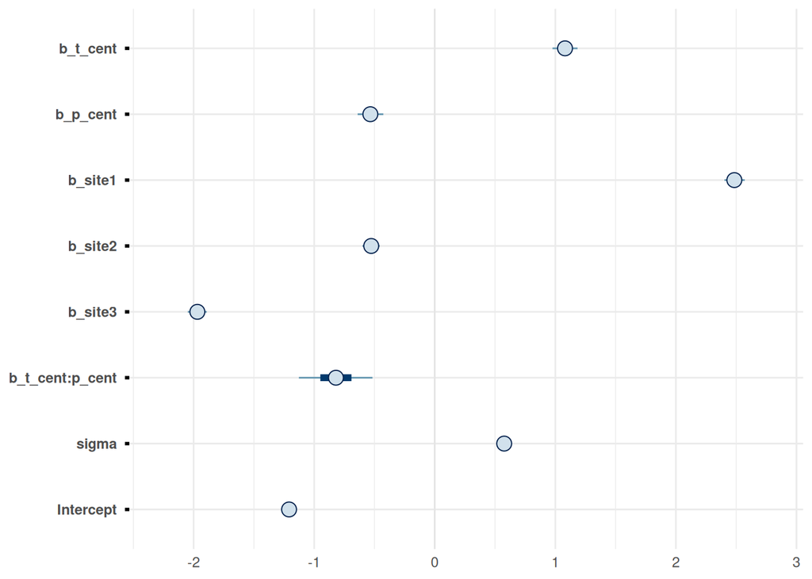

```r
mcmc_intervals(fit_int_demean_x, pars = show)
```

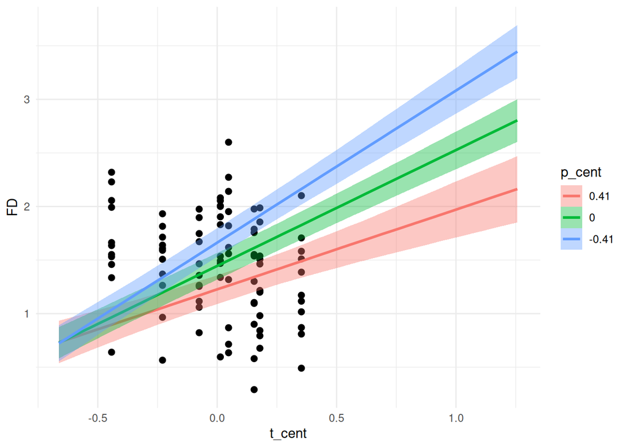

```r
conditional_effects(fit_int_demean_x, effects = "t_cent:p_cent")
```

```r
fit_int_dd_x <- update(fit_int_std_x,
                       FD ~ t_cent + p_cent + t_x_p + site,
                       newdata = sim_int_x,
                       file = "fits/sim/sim.int.dd.x",
                       seed = 295)

fit_int_dd_x
```

```
 Family: gaussian
  Links: mu = identity
Formula: FD ~ t_cent + p_cent + t_x_p + site
   Data: sim_int_x (Number of observations: 512)
  Draws: 4 chains, each with iter = 2000; warmup = 1000; thin = 1;
         total post-warmup draws = 4000

Regression Coefficients:
          Estimate Est.Error l-95% CI u-95% CI Rhat Bulk_ESS Tail_ESS
Intercept    -1.05      0.03    -1.10    -1.00 1.00     6454     3014
t_cent        1.08      0.06     0.96     1.20 1.00     6093     3299
p_cent       -0.53      0.06    -0.66    -0.41 1.00     6478     3169
t_x_p        -0.82      0.18    -1.16    -0.46 1.00     5630     3241
site1         2.49      0.05     2.39     2.59 1.00     4287     3087
site2        -0.51      0.04    -0.59    -0.42 1.00     5086     3249
site3        -1.96      0.05    -2.05    -1.86 1.00     4611     2652

Further Distributional Parameters:
      Estimate Est.Error l-95% CI u-95% CI Rhat Bulk_ESS Tail_ESS
sigma     0.58      0.02     0.54     0.61 1.00     6267     2942

Draws were sampled using sample(hmc). For each parameter, Bulk_ESS
and Tail_ESS are effective sample size measures, and Rhat is the potential
scale reduction factor on split chains (at convergence, Rhat = 1).
```

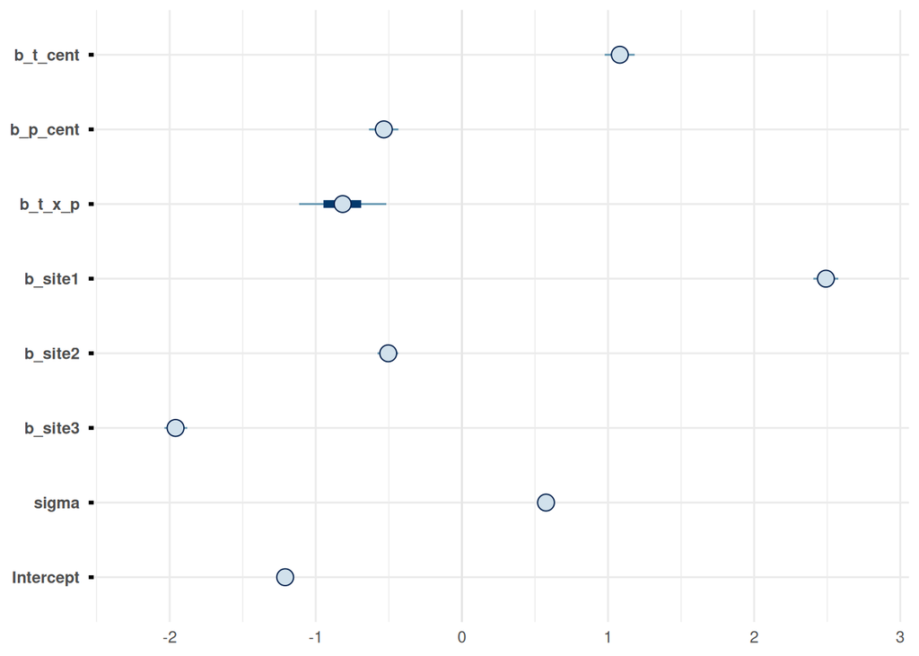

```r
mcmc_intervals(fit_int_dd_x, pars = show)
```

## 6.3 Conclusions

From these simulations, it is clear that the uncentered interaction term cannot recover the within-site interaction, unconfounded by time-invariant factors, because it also contains the cross-level interactions. Building the double-demeaned interaction by hand or interacting the centered variables is equivalent, because the site fixed effect absorb the site-level interaction term (the last term), but the latter has the advantage of being able to use standard prediction machinery, because the interaction term is recognized as such.

## References

Giesselmann, Marco, and Alexander W. Schmidt-Catran. 2022. “Interactions in Fixed Effects Regression Models.” *Sociological Methods & Research* 51 (3): 1100–1127. https://doi.org/10.1177/0049124120914934.

Hamaker, Ellen L., and Bengt Muthén. 2020. “The Fixed Versus Random Effects Debate and How It Relates to Centering in Multilevel Modeling.” *Psychological Methods* 25 (3): 365–79. https://doi.org/10.1037/met0000239.

Mundlak, Yair. 1978. “On the Pooling of Time Series and Cross Section Data.” *Econometrica* 46 (1): 69–85. https://doi.org/10.2307/1913646.